# ds202_hw3

# 5 How does the tipping amount (tip) depend on the overall bill (total_bill)? Describe the relationship in words. Describe at least two types of anomolies in the plot. What do they mean? Use the ggplot2 to make a chart.

Answer: Relationship between the variables tip and total_bill seems to be positive, moderately weak to moderate strength and linear. There seems to be an outliers and as the bill total gets higher- the points seems to spread out like a megaphone. The amount that is left for tip depends on the bill total bc in general, most people leave a percentage of the bill total (I always leave 20%) but that is not the case for everyone.

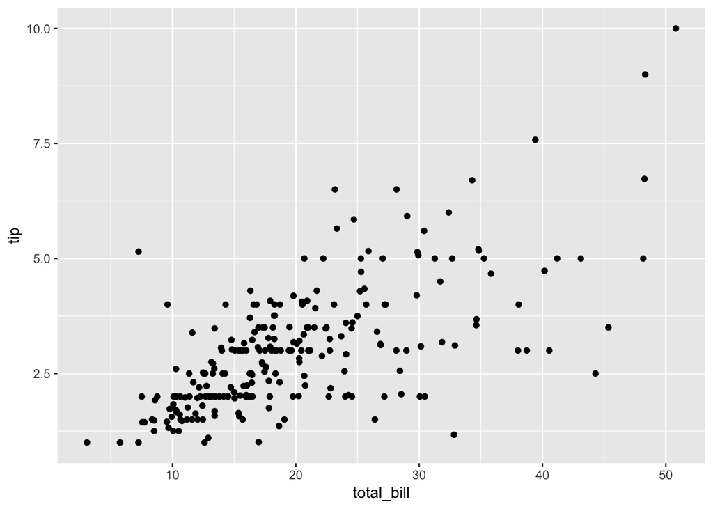

```r
library(ggplot2)
ggplot(tips, aes(x=total_bill, y=tip)) + geom_point()
```

# 6 Introduce a variable ‘tiprate’ into the data set, that incorporates the rate of tips. What is the average rate for tips?

Answer: Average rate for tips: 0.16080 or 16.08%

```r
tiprate <- tips$tip/tips$total_bill
summary(tiprate)
```

```
##    Min. 1st Qu.  Median    Mean 3rd Qu.    Max.
## 0.03564 0.12913 0.15477 0.16080 0.19148 0.71034
```

```r
?tips
```

# 7 Make a boxplot of the rate by time. The x-axis should be ordered by lunch and then dinner. Use the ggplot 2 package to make a chart.

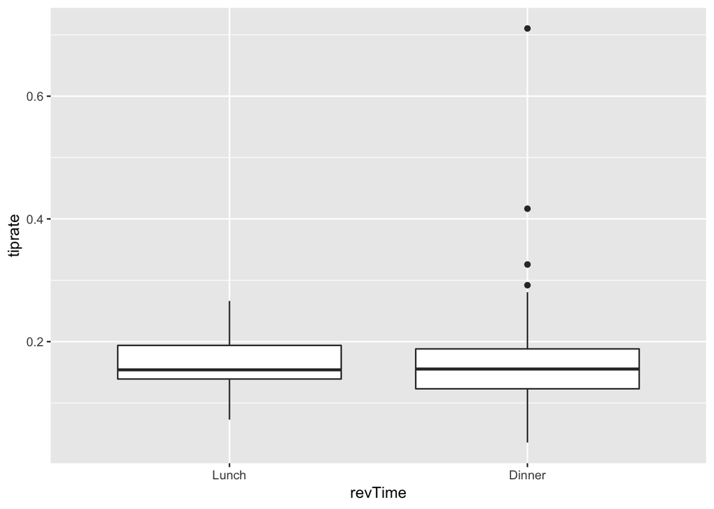

```r
time <- tips$time
lvlTime <- levels(time)
revTime <- factor(time, levels = rev(lvlTime))
ggplot(tips, aes(x=revTime, y=tiprate)) + geom_boxplot()
```

# 8 How does smoking behavior and gender of the person who pays impact the relationship between tip and total bill? Find a visualization that incorporates all four variables. Interpret the result.

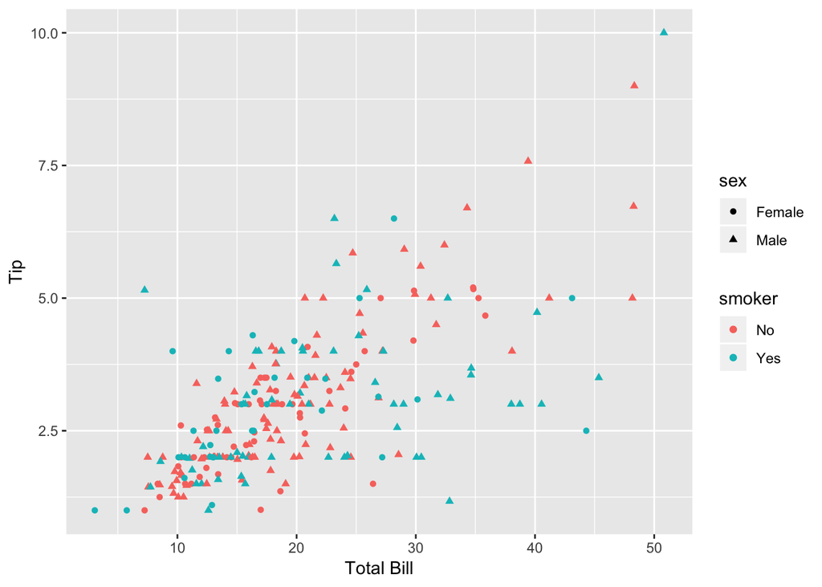

```r
ggplot(tips, aes(x=total_bill, y=tip, color=smoker, shape=sex)) + geom_point() +
  xlab("Total Bill") + ylab("Tip")
```

# 9 Use ggplot2 to find a graphical summary of the relationship between day of the week and gender of the person paying the bill. What can you say about this relationship?

Answer: On Thurs&Fri, there seems to be an even amount of people but on Sat&Sun there is a pretty significant change. The number of men doubles, at the least, the amount of women.

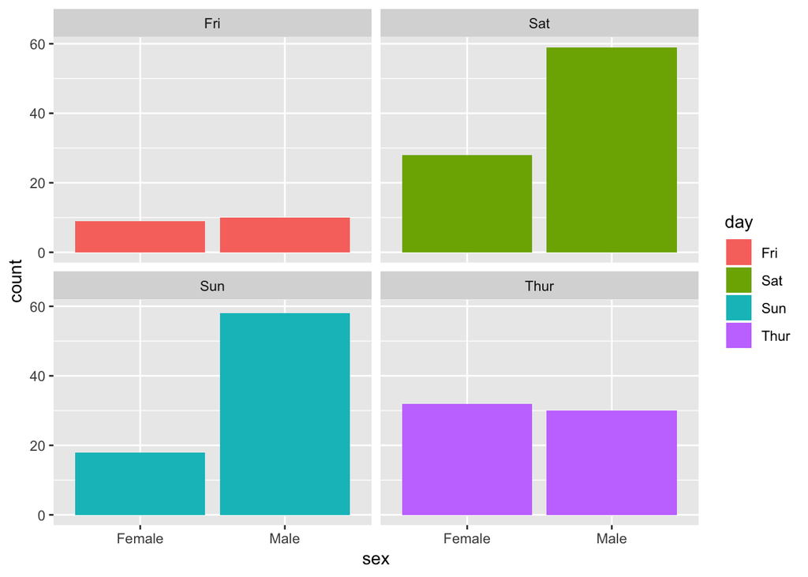

```r
ggplot(tips, aes(x=sex, fill=day)) + geom_bar() + facet_wrap(~day)
```